# MATH70076: Data Science - Formative Assessment

MSc in Statistics 2026/27, Imperial College London

Author

06087464

**Deadline: Monday 12 October 2026 at 13:00.**

*For this formative assessment you should submit two files via the Imperial College VLE on Canvas by the deadline stated above. Your files should be named as follows:*

- `YOURCID-MATH70076-formative-assessment.pdf`: your rendered report,
- `YOURCID-MATH70076-formative-assessment.zip`: a zip file containing the relevant source code to generate your report.

*All submitted materials should be clearly presented and be understandable as stand-alone documents.*

*Please note that large files can take quite some time to upload. Ensure that you upload each document to the correct part of the learning space in a timely manner.*

*This mock coursework is a formative assessment and so will not contribute to your overall grade for the module. It is designed for you to practice the skills you have learned in the first workshop and to get feedback on your reflective writing style. This activity is expected to take approximately 6 hours of individual effort. Assessment criteria are given in the “set yourself up for success” boxes. Satisfying 18 or more out of these 23 criteria corresponds to a notional “pass” grade.*

*In submitting this mock assessment you certify that it is entirely your own work, apart from where otherwise acknowledged, and includes no plagiarism. Note that software tools are used as part of plagiarism detection.*

## Background

### Generalized Pareto Distribution

The Generalized Pareto Distribution (GPD) is a flexible family of continuous probability distributions that arises naturally in extreme value theory, particularly for modelling the distribution of excesses over a threshold. It is parametrised by a shape parameter $\xi \in \mathbb{R}$, a scale parameter $\sigma > 0$, and a location parameter $u \in \mathbb{R}$. Its cumulative distribution function (CDF) is given by

$$F(x;\,\sigma,\xi, u) =
\begin{cases}
1 - \left(1 + \dfrac{\xi (x-u)}{\sigma}\right)_+^{-1/\xi}, & \xi \neq 0, \, x \geq u; \; \\[1.2em]
1 - \exp\!\left(-\dfrac{x-u}{\sigma}\right), & \xi = 0, \, x \geq u;
\end{cases}
\tag{1}$$

where $x_+ = \max(x,0)$ and its probability density function (PDF) is

$$f(x;\sigma,\xi,u) =
\begin{cases}
\dfrac{1}{\sigma}\left(1 + \dfrac{\xi (x-u)}{\sigma}\right)_+^{-1/\xi - 1}, & \xi \neq 0, \\[1.2em]
\dfrac{1}{\sigma}\exp\!\left(-\dfrac{x-u}{\sigma}\right), & \xi = 0,
\end{cases}
\tag{2}$$

defined on the same support as the CDF. The GPD encompasses a variety of tail behaviours:

- when $\xi > 0$ the GPD has heavy, slowly decaying tails,
- in limiting case when $\xi \rightarrow 0$ the GPD reduces to an exponential distribution;
- when $\xi < 0$ the GPD has light, quickly decaying tails with a finite upper endpoint of $x^+ = u - \sigma / \xi$.

### Probability Integral Transform

The probability integral transform states that if a random variable $X$ has a continuous cumulative distribution function $F_X(x)$, then the transformed variable $A = F_X(X)$ follows a uniform distribution on $[0,1]$. Conversely, if $F$ is an invertible function then $Y = F^{-1}_X(A)$ has the same distribution as $X$.

## Questions

### Question 1

Derive an expression for the inverse cumulative distribution function (also known as the quantile function) $F^{-1}_X: [0,1] \rightarrow [u, x^+]$ of $X \sim \text{GPD}(u, \sigma, \xi)$. Your answer should refer to at least one equation given in the background material.

**TipSet yourself up for success**

Does your answer contain:

- a few sentences of text describing your approach to the problem;
- a reference to at least one equation from the background section;
- a correctly formatted LaTeX equation;
- a valid approach to the problem and correct expression.

### Answer 1

The problem requires to derive an inverse cumulative distribution function for the Generalized Pareto Distribution. In order to obtain one we must first define a new variable $p \in [0,1]$ such that $F_X(x) = p$ and solve for $x$ in terms of $p$, which would give us $F^{-1}_X$. Since Equation 1 has tow cases, we must derive $F^{-1}_X$ for each of them, starting with the simpler case when $\xi = 0$.

#### Case $\xi = 0$:

In this case we have that $F_X(x) = p = 1 - \exp\!\left(-\dfrac{x-u}{\sigma}\right)$ with $x \geq u$, so solving for $x$ we get

$$F^{-1}_X(p) = u - \sigma \ln(1 - p)$$

#### Case $\xi \neq 0$:

In this case we have that $F_X(x) = 1 - \left(1 + \dfrac{\xi (x-u)}{\sigma}\right)_+^{-1/\xi}$ with $x \geq u$. This case has an expression of the form $x_+ = \max(x,0)$ meaning it can also be divided in two sub cases:

$$\left(1 + \dfrac{\xi (x-u)}{\sigma}\right) > 0
\tag{3}$$
and
$$\left(1 + \dfrac{\xi (x-u)}{\sigma}\right) \leq 0
\tag{4}$$

Since we have that $x \geq u$ and $\sigma > 0$ we know that if $\xi >0$ then Equation 3 holds, so solving for $x$ gives us

$$F^{-1}_X(p) = \dfrac{\sigma}{\xi} \left((1-p)^{-\xi} - 1 \right) + u
\tag{5}$$

If $\xi < 0$ then we have to find the values of $x$ for which Equation 4 holds. By solving the inequality we get that Equation 4 holds when $x \geq u + \dfrac{\sigma}{|\xi|}$, which would give us that $F_X(x) = 1$.

Otherwise, Equation 3 is true when $u \leq x < u + \dfrac{\sigma}{|\xi|}$ so we are back with the solution Equation 5.

Now using $F_X(x)$ to get the conditions in terms of $p$ we get that $F_X(u) = 0$ for all cases and $F_X(x) = 1$ when $\xi < 0, \, x \geq u + \dfrac{\sigma}{|\xi|}$. Since the quantile function is defined as $F_X^{-1}(p) = \inf\{x : F_X(x) \geq p\}$, the point $p = 1$ doesn’t need a separate case: reading $(1-p)^{-\xi}$ there as $+\infty$ for $\xi > 0$ and as $0$ for $\xi < 0$ gives the empty set’s infimum in the first case and $u + \frac{\sigma}{|\xi|}$ in the second. So we get

$$F^{-1}_X(p; \sigma, \xi, u) =
\begin{cases}
u - \sigma \ln(1 - p), & \xi = 0, \, 0 \leq p \leq 1;
\\[1.2em]
u + \dfrac{\sigma}{\xi} \left((1-p)^{-\xi} - 1 \right), & \xi \neq 0, \, 0 \leq p \leq 1;
\end{cases}$$

### Question 2

*For this question you should display the R code you use to define and document `qgpd()` within the main text of your report.*

1. Write and document your own function `qgpd()` to calculate quantiles of a given generalized Pareto distribution. Your function should have inputs and behaviour similar to the built-in R functions such as `qnorm()` and `qunif()` and check that inputs are in the correct format.
2. Suppose a random variable $X$ follows a Generalized Pareto Distribution with threshold parameter $u=1.5$, scale parameter $\sigma = 2$ and shape parameter $\xi = -0.4$. Use your function to find quantiles $x_p$ for $p = 0.5, 0.75, 0.99$ (i.e. for each $p$ find the value for which $\Pr(X < x_p) = p$).

**TipSet yourself up for success**

Does your answer:

- contain a valid R function definition;
- document the expected inputs, outputs and behaviours of that function;
- check the validity of inputs;
- handle any edge-cases in an appropriate way;
- return the correct quantile values?

### Answer 2

```r
#' Quantile function for the Generalized Pareto Distribution
#'
#' Returns the quantiles of the Generalized Pareto Distribution with
#' location parameter 'u', scale parameter 'sigma', and shape parameter
#' 'xi'.
#'
#' @param p Vector of probabilities.
#' @param u Vector of the location parameter.
#' @param sigma Vector of the scale parameter.
#' @param xi Vector of the shape parameter.
#' @param lower.tail Logical; probabilities are P(X <= x) if `TRUE` and
#'   P(X > x) otherwise.
#' @param log.p Logical; probabilities are given as log(p) if `TRUE` and
#'   just p otherwise.
#'
#' @return Numeric vector of quantiles. Returns `NaN` (with a warning)
#'   for invalid inputs.
#'
#' @examples
#' qgpd(0.95, sigma = 2)
#' qgpd(c(0.5, 0.9), u = c(0, 10))

qgpd = function(p, sigma=1, xi=0, u=0, lower.tail=TRUE, log.p=FALSE){

  # handle wrong data types as qnorm
  if (
    any(
      !is.numeric(p),
      !is.numeric(sigma),
      !is.numeric(xi),
      !is.numeric(u)
    )
  ) stop("Non-numeric argument to mathematical function")

  # turn log(p) into p
  if (log.p) {
      p = exp(q)
  }
  # return upper tail
  if (!lower.tail) {
    p = 1 - p
  }

  # handle vectors as qnorm
  max_n = max(length(p), length(sigma), length(xi), length(u))
  p = rep_len(p, max_n)
  sigma = rep_len(sigma, max_n)
  xi = rep_len(xi, max_n)
  u = rep_len(u, max_n)

  # define the return vector
  out <- numeric(max_n)

  # case xi = 0
  mask = xi == 0 # boolean mask x = 0
  out[mask] = u[mask] - sigma[mask] * log(1 - p[mask])

  # case x != 0
  mask = xi != 0 # boolean mask x != 0
  out[mask] = (
    u[mask] + (sigma[mask] / xi[mask]) * ((1 - p[mask])^(-xi[mask]) - 1)
  )

  # force NaNs in computable but not allowed cases (as with qnorm and qunif)
  mask = (
    (p > 1 | p < 0)
    | (sigma < 0)
  ) # boolean mask for values not allowed
  if (any(mask, na.rm = TRUE)) {
    out[which(mask)] <- NaN
    warning("NaNs produced")
  }


  return(out)
}
```

```r
# testing the function
u = 1.5
sigma = 2
xi = -0.4
p = c(0.5, 0.75, 0.99)

qgpd(p, sigma, xi, u)
```

```
[1] 2.710709 3.628254 5.707553
```

```r
# incorrect data types test
qgpd(p = "0.5")
```

```
Error in `qgpd()`:
! Non-numeric argument to mathematical function
```

```r
# invalid inputs
qgpd(p = -2, xi=1)
```

```
[1] NaN
```

```r
qgpd(p = 0.5, sigma = -4)
```

```
[1] NaN
```

### Question 3

*For this question, all R code should be displayed only within the appendix, not in the main report.*

The file `gpd_samples.csv` contains six sets of random variates generated from different generalized Pareto distributions. The details of the generalized Pareto distributions used are summarized in `gpd_parameters.csv`. Unfortunately some of the parameter sets were recorded incorrectly.

Within a single figure, construct a series of quantile-quantile plots to identify which datasets are inconsistent with their stated distributions. You should both justify your conclusions and describe your level of confidence in your findings.

**TipSet yourself up for success**

Does your solution contain:

- at least one quantile-quantile plot;
- six qq-plots in a single figure;
- use of loops, vectorisation, or function definitions to avoid repetitive code.
- figures with clear text, useful captions and appropriate visual mapping of data;
- a few paragraphs describing and justifying your findings and referencing the figure;

### Question 4

*For this question, all R code should be displayed only within the appendix, not in the main report.*

A hydrologist is interested in understanding the river flow at a location that is historically prone to flooding. There is a river flow gauge nearby which measures river flow in units of cubic meters per second ($\text{m}^3/\text{s}$ or cumecs). Based on her knowledge of other rivers, the hydrologist proposes that for this river gauge:

- the distribution of river flow values is constant over time
- for river flows exceeding 75 cumecs, it is appropriate to model these data as independent and identically distributed GPD($\sigma =29.7$, $\xi=0.62$, $u = 0$).

Use `riverflow_2015-2024.csv` to conduct an exploratory investigation of whether these proposals are valid for the dataset provided. Summarise your findings in 250-350 words, supporting these with a collection of 4 visualisations/figures.

**TipSet yourself up for success**

Does your answer contain:

- 400-500 words of text clearly describing your choice of visualisations, their interpretation and your conclusions about the validity of each assumption,
- A series of 4 visualisations / figures,
- A varied and appropriate choice of figures to investigate each of the hydrologist’s proposals,
- Figures with clear text, useful captions and appropriate visual mapping of data;
- At least one reference to each visualisation within the main text.

### Answer 4

To evaluate the hydrologist’s first proposal that the river flow distribution remains constant over time, we can look at Figure 2 which shows the time series of the river flow and Figure 3 which shows the annual distribution of river flow. The time series plot shows some seasonal cycles, but it is dominated by a single, massive extreme flood event at the end of 2015 that spikes above 1000 cumecs. No other year matches this intensity. Looking at the annual boxplot, the middle boxes slowly creep upward from 2015 to 2024. Additionally, the maximum peaks and the distribution of extreme outliers change dramatically from one year to the next. Because the overall distribution and the behavior of extreme events are shifting over the decade, the first proposal of a constant distribution over time is invalid.

The second proposal states that flows exceeding 75 cumecs follow a specific Generalized Pareto Distribution with scale parameter $\sigma = 29.7$, shape parameter $\xi = 0.62$ and location parameter $u = 0$. We test this using Figure 5, which shows the observed and theoretical GPD distributions, and Figure 4, which shows a Q-Q Plot of the observed river flow excess againts the theoretical values. The data points track the red dashed reference line nicely at first, but then bend completely below it for all higher theoretical values. This means the observed extreme points are much smaller than what the hydrologist’s model predicts. This mismatch is confirmed by the histogram in Figure 5, where the red theoretical density curve drops off too quickly at first and then expects a much longer, thicker tail than what was actually recorded in the river. Because the proposed parameters systematically overestimate the severity of the largest floods, the second proposal is also invalid.

Once again this conclusions come only from a visual analysis of the data and to formalize them, a statistical framework would be required. First, the assumption of a constant distribution over time could be verified using a non-parametric trend test alongside a moving-window variance analysis to check for changes in the mean and spread. Second, the validity of the specific GPD model parameters could be rigorously evaluated using a goodness-of-fit test such as the Anderson-Darling or the Kolmogorov-Smirnov tests, which would evaluate if the observed data deviates significantly from the proposed curve. Although these tests would provide a definitive, formal confirmation, the visual analysis presented remains highly revealing and clearly demonstrates that both of the hydrologist’s proposals are likely to be invalid.

**TipSet yourself up for success**

- Does your document render without any formatting issues?

## Question 5 Reflective Summary

Describe, evidence and reflect on the process of constructing the visualisations in your answer to Question 4.

Your response should be 300-400 words and might, for example, comment on:

- why you chose these forms of visualisation and what alternatives you considered;
- a challenge you faced or something that you learned while making the visualisations;
- how you might approach this task differently with more time or for a different intended audience.

**TipSet yourself up for success**

Does your response:

- describe how you engaged with the visualisation activity;
- give specific evidence of that engagement;
- critically reflection on that engagement?

### Reflective Summary

During the evaluation of the hydrologist’s proposals, first I carefully analyzed the two claims: what it would mean for them to be true and thus how would the data look across different visualizations. Since the first proposition involves a time component I initially selected a standard time series line plot. This allow me to see if there’s any clear seasonal pattern to the data and if it follows some trend. Once I generated the plot, I discovered a massive extreme event in late 2015 exceeding 1,000 cumecs. To analyze this further I considered using an aggregated function for the time series, such as plotting the mean over time bounded by the mean plus and minus two standard deviations, but instead I chose an annual boxplot to look at the entire distribution’s evolution. By adjusting the vertical axes the boxplot it became clear that the median and upper quartiles drifted upward over the decade, proving the distribution was not constant.

Although the annual boxplots were an effective choice for capturing the upward drift in the distributions, plotting the mean over time with standard deviation bands would have also been an interesting visualization and might have been a more effective plot for a general public. For this approach I would have aggregated the data at a monthly level instead of annually and this could have revealed hidden seasonal dynamics, though the boxplots alone were enough evidence to prove the hydrologist’s proposal false.

To evaluate the second proposal regarding the distribution of the river flow’s excesses I immediately chose to use a Q-Q plot comparing the observed data with theoretical values generated using the `qgpd()` function previously constructed. This decision was motivated not only by it’s utility to evaluate if the data matches the proposed distribution but also because it neatly tied up all the previous exercises in a final section. For the second plot I originally thought about investigating the “independent and identically distributed” (i.i.d.) part of the proposal, so I considered creating an Autocorrelation Function (ACF) plot, but at the end I chose to focus only on the shape of the distribution. This lead me to choose a different visualization comparing the distribution of the observed values with the theoretical GPD using a histogram for the actual data and a line showing the proposed probability density function. With more time, I would have used Maximum Likelihood Estimation to plot the data’s true optimal parameters alongside the hydrologist’s proposed distribution.

# Code Appendix

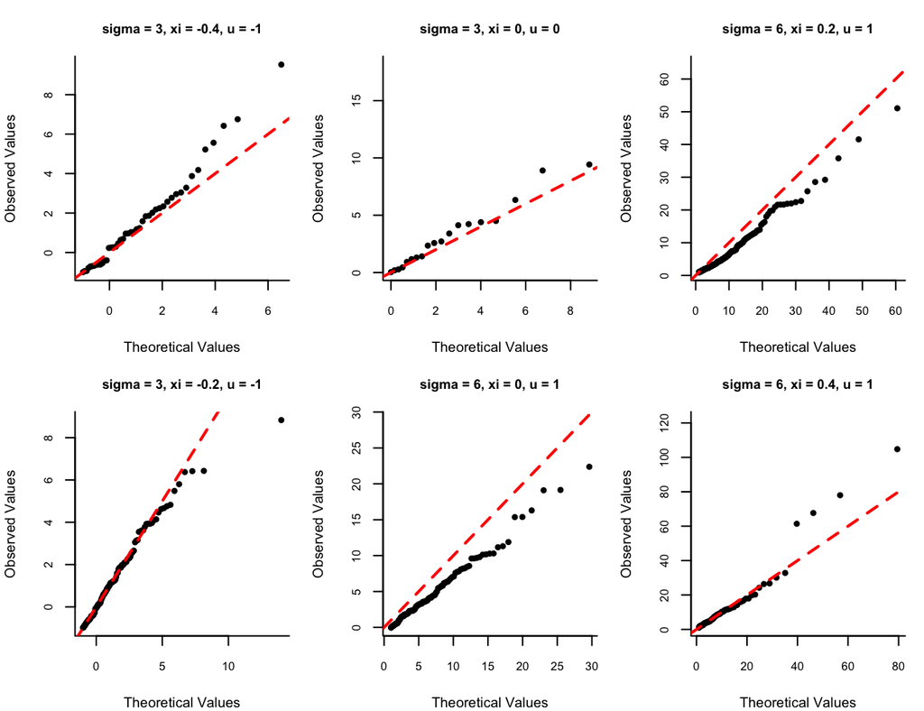

Figure 1: Q-Q plots for the different samples

```r
library(glue)

gpd_samples = read.csv("gpd_samples.csv")
gpd_parameters = read.csv("gpd_parameters.csv")

ids_len = nrow(gpd_parameters)
fig = par(
  mfcol = c(2, ids_len/2), mar = c(4, 4, 3, 1),
  cex.axis = 0.75, cex.lab = 0.9, cex.main = 0.85
)

for (i in seq_len(ids_len)) {

  dist_id = gpd_parameters$id[i]

  u = gpd_parameters[gpd_parameters$id == dist_id,]$u
  sigma = gpd_parameters[gpd_parameters$id == dist_id,]$sigma
  xi = gpd_parameters[gpd_parameters$id == dist_id,]$xi

  X_obs = gpd_samples[gpd_samples$set_id == dist_id, ]$value
  X_obs = sort(X_obs)
  n = length(X_obs)

  p = seq(0, 1, length.out = n)
  X_theo = qgpd(p,sigma, xi, u)

  plot(
    X_theo,
    X_obs,
    pch=20,
    main=glue("sigma = {sigma}, xi = {xi}, u = {u}"),
    xlab="Theoretical Values",
    ylab="Observed Values",
    bty="l"
  )
  abline(a = 0, b = 1, col = "red", lwd = 2, lty = 2)
}
```

```r
df = read.csv("riverflow_2015_2024.csv")
df$date = as.Date(df$date)
```

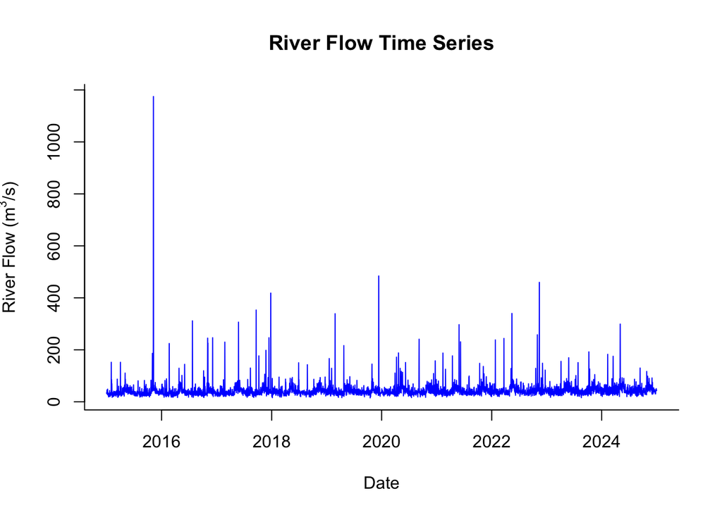

Figure 2: Time series of the River Flow

```r
plot(
  df$date,
  df$flow,
  type = "l",
  col = "blue",
  xlab = "Date",
  ylab = bquote("River Flow (" * m^3 * "/s)"),
  main = "River Flow Time Series",
  bty = "l",
)
```

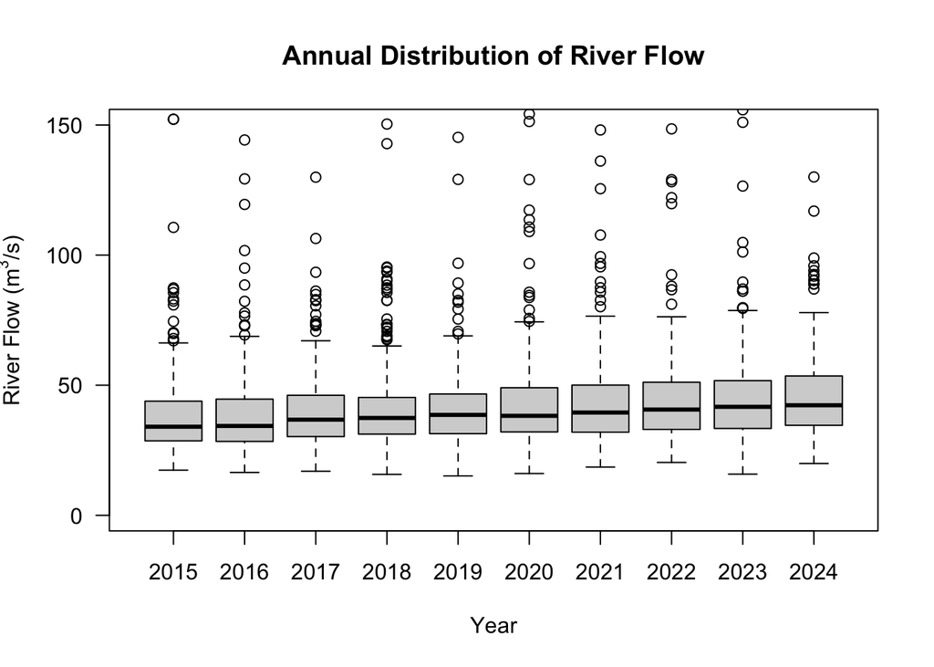

Figure 3: Annual distribution of the River Flow

```r
df$year <- format(df$date, "%Y")
boxplot(
  flow ~ year,
  data = df,
  las = 1,
  bty = "l",
  xlab = "Year",
  ylab = bquote("River Flow (" * m^3 * "/s)"),
  main = "Annual Distribution of River Flow",
  ylim = c(0, 150)
)
```

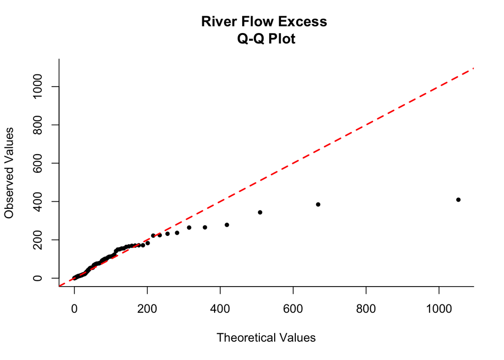

Figure 4: Q-Q plot of the excess River Flow

```r
X_obs = df[df$flow > 75, ]$flow
X_obs = X_obs - 75 # get only excesses
X_obs = sort(X_obs)
n = length(X_obs)

sigma = 29.7
xi = 0.62
u = 0

p = seq(0, 1, length.out = n)
X_theo = qgpd(p,sigma, xi, u)

plot(
  X_theo,
  X_obs,
  pch=20,
  main=glue("River Flow Excess \nQ-Q Plot"),
  xlab="Theoretical Values",
  ylab="Observed Values",
  bty="l"
)
abline(a = 0, b = 1, col = "red", lwd = 2, lty = 2)
```

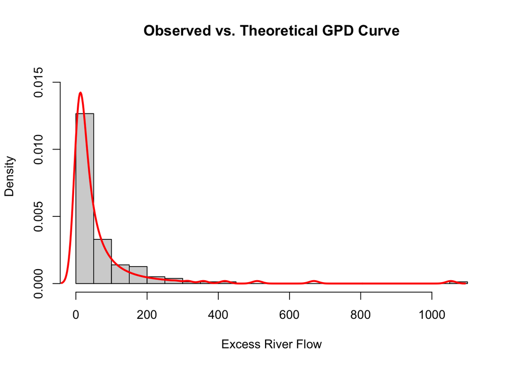

Figure 5: Observed vs theoretical excess distribution

```r
hist(
  X_obs,
  probability = TRUE,
  breaks = 30,
  bty = "l",
  xlab = "Excess River Flow",
  ylab = "Density",
  main = "Observed vs. Theoretical GPD Curve",
  ylim = c(0, 0.016)
)

lines(density(X_theo), col='red', lwd=2.5)
```